# RNA-seq para dummies

Práctica 2: Fundamentos de R

Erick I. Navarro-Delgado

17/03/2021

# Introducción

En esta práctica veremos distintos paquetes que nos serán útiles para realizar nuestro análisis de expresión diferencial.

El objetivo es describir distintas herramientas no necesariamente espcíficas del análisis de datos ómicos que nos permitirán manipular nuestros datos.

Utilizando las funciones aquí vistas, seremos capaces de realizar en la siguiente práctica el análisis de expresión diferencial.

# Operadores relacionales y lógicos

## Operadores relacionales

Para empezar, veremos los [**operadores relacionales**](https://bookdown.org/jboscomendoza/r-principiantes4/operadores-relacionales.html). Estos operadores son signos que nos permiten comparar distintos valores (en el caso de utilizarlos con valores numéricos). Estas comparaciones las conocemos ya bastante bien, y corresponden al *mayor que* (>), *menor que* (<) e *igual que* (==), junto con sus variantes *mayor o igual qué* (>=) y *menor o igual que* (<=).

El resultado de hacer estas comparaciones será un valor booleano que nos indique si esa comparación es verdadera (`TRUE`) o falsa (`FALSE`).

Ahora, veamos algunas comparaciones muy simples en R, así como sus resultados:

```r
4 == 4
```

```
## [1] TRUE
```

```r
5 > 3
```

```
## [1] TRUE
```

```r
3 < 5
```

```
## [1] TRUE
```

```r
4 <= 6
```

```
## [1] TRUE
```

```r
7 >= 7
```

```
## [1] TRUE
```

```r
7 != "a"
```

```
## [1] TRUE
```

## Operadores lógicos

Los [**operadores lógicos**](https://bookdown.org/jboscomendoza/r-principiantes4/operadores-logicos.html) son utilizados como parte de las operaciones del álgebra booleana para describir relaciones lógicas. Aquí se utilizan los operadores *Y* (&), *O* (|) y *NOT* (!) para saber si una oración lógica es verdadera o falsa.

Vemoas unos ejemplos para que se aclare el concepto.

```r
numero = 10
numero > 7 & numero !=5
```

```
## [1] TRUE
```

```r
numero > 7 | numero !=5
```

```
## [1] TRUE
```

```r
numero > 7 | numero ==5
```

```
## [1] TRUE
```

En estos ejemplos, mezclamos operadores relacionales y lógicos y observamos cómo se pueden utilizar para saber si unas condiciones dadas se están cumpliendo en nuestra oración. Estos conceptos serán clave para hacer **subsets** de nuestros datos seleccionando únicamente grupos que cumplan con las condiciones que queramos.

# Subsetting

En esta sección veremos cómo utilizar los operadores lógicos y relacionales para seleccionar subconjuntos de datos. Para empezar, creemos un data frame de prueba con distintas columnas

```r
df_test = data.frame(Numeros = c(1,2,3,4,5,6,7),
                     Frutas = c("piña","sandia","melon", "manzana","guanabana","guayaba","fresa"),
                     row.names = c("a","b", "c","d","e","f", "g"))

df_test
```

```
##   Numeros    Frutas
## a       1      piña
## b       2    sandia
## c       3     melon
## d       4   manzana
## e       5 guanabana
## f       6   guayaba
## g       7     fresa
```

Ahora que tenemos este data frame, podemos acceder a elementos únicos dentro de él al indicar la fila y columna que queremos dentro de corchetes.

```r
df_test[1,2] #Acceder a un solo elemento
```

```
## [1] "piña"
```

## Operadores relacionales

Pero, ¿qué tal si queremos acceder a todos los que tienen un valor menor a 4 en la columna números?  
Como puedes ver, si escribimos `df_test$Numeros < 4`, obtenemos un vector con `TRUE` o `FALSE` dependiendo de si el elemento de `df_test$Numeros` es o no menor a cuatro. Podemos utilizar este vector booleano para seleccionar únicamente las filas que cumplan con esto al poner la condición en la posición que corresponde a las filas al momento de acceder a los valores el data frame. La posición de la columna se deja vacía para denotar que de esa dimensión queremos seleccionar a todos los elementos.

```r
df_test[df_test$Numeros < 4, ]
```

```
##   Numeros Frutas
## a       1   piña
## b       2 sandia
## c       3  melon
```

Finalmente, podemos asignar esto a una nueva variable *abc*

```r
abc = df_test[df_test$Numeros < 4, ]
```

Esto mismo se puede hacer con la función subset, donde se indica el data frame a subsetear y posteriormente la condición para filtrar las filas

```r
subset(df_test, Numeros < 4)
```

```
##   Numeros Frutas
## a       1   piña
## b       2 sandia
## c       3  melon
```

También podemos utilizar el operador `%in%`, el cual te permite seleccionar con base en un conjunto de valores o palabras que son elementos en un vector dado. Por ejemplo, si tuvieramos un vector con las frutas piña, papaya y melón podemos utilizarlo como criterio para quedarnos únicamente con los elementos que coincidan con él en una columna de nuestro data frame.

```r
frutas_ricas = c("piña","papaya", "melon")
subset(df_test, Frutas %in% frutas_ricas)
```

```
##   Numeros Frutas
## a       1   piña
## c       3  melon
```

Como puedes ver, básicamente lo que hicimos fue pedirle a subset que nos seleccionara las filas cuyos valores de Frutas coincidieran con los elementos ubicados en el vector frutas_ricas

También podemos utilizar varias condiciones para hacer subsets más complejos, como podría ser este ejemplo, donde queremos encontrar los que están en `frutas ricas` o cuyo número sea mayor a 5.

```r
subset(df_test, Frutas %in% frutas_ricas | Numeros > 5)
```

```
##   Numeros  Frutas
## a       1    piña
## c       3   melon
## f       6 guayaba
## g       7   fresa
```

## Búsqueda de patrones

En este bloque, veremos cómo seleccionar filas cuyos elementos de una columna posean un patrón de texto específico.  
Con la función `grepl`, podemos indicar un patrón como primer argumento de la función, y después un vector en el cual hacer la búsqueda. Como regreso, obtenemos un vector con valoreas booleanos que indica, por posición, dónde hubo un match con el patrón indicado

```r
grepl("an",df_test$Frutas)
```

```
## [1] FALSE  TRUE FALSE  TRUE  TRUE FALSE FALSE
```

Si eres observador, podrás notar que, al igual que hicimos en la sección anterior, este tipo de vectores podemos usarlos para hacer un subset al poner la condición entre corchetes en la posición que corresponde a las filas.

```r
df_test[grepl("an",df_test$Frutas),]
```

```
##   Numeros    Frutas
## b       2    sandia
## d       4   manzana
## e       5 guanabana
```

Así, obtenemos un subgrupo del dataset donde todas las frutas contienen el patrón "an" en la columna *Frutas*.

# Joins

En este bloque, veremos cómo mezclar dos data frames con base en una columna común para crear uno en donde la información de ambos esté presente.

Imaginemos que tenemos un data frame nuevo en el cual tenemos el precio de cada una de las frutas.

```r
precio = data.frame(Frutas = c("guanabana", "guayaba", "papaya", "granada"),
                    precio = c(1,2,3,4))
```

Para unir ambos data frames para obtener uno nuevo, hacemos un join utilizando el paquete `dplyr`. Dentro de los distintos tipos de joins que podemos hacer, veremos tres: el left, right e inner.

El left join, anexa al data frame número uno que indicas en los argumentos de la función las columnas del data frame número dos que coincidan con él en la columna indicada (observa que ambas columnas deben de llamarse igual). En los casoso donde no haya un match, se ponen valores `NA`. Los valores presentes en el data frame derecho que no tengan una contraparte en el izquierdo se ignoran.

```r
library(dplyr)
left_join(df_test, precio, by = "Frutas")
```

```
##   Numeros    Frutas precio
## 1       1      piña     NA
## 2       2    sandia     NA
## 3       3     melon     NA
## 4       4   manzana     NA
## 5       5 guanabana      1
## 6       6   guayaba      2
## 7       7     fresa     NA
```

En el right join, se hace lo mismo, pero pegando ahora las columnas del data frame izquierdo al derecho. De manera similar a lo que vimos arriba, los valores presentes en el data frame izquierdo que no tengan una contraparte en el derecho se ignoran.

```r
right_join(df_test, precio, by = "Frutas")
```

```
##   Numeros    Frutas precio
## 1       5 guanabana      1
## 2       6   guayaba      2
## 3      NA    papaya      3
## 4      NA   granada      4
```

Finalmente, tenemos el inner join, donde el data frame obtenido poseerá únicamente las filas donde ambos data frames tengan los mismos valores en la categoría indicada.

```r
inner_join(df_test, precio, by = "Frutas")
```

```
##   Numeros    Frutas precio
## 1       5 guanabana      1
## 2       6   guayaba      2
```

```r
final = inner_join(df_test, precio, by = "Frutas")
```

Observa la diferencia entre los data frames que obtuvimos en cada uno de los casos para entender cómo funciona cada uno y, en caso de tener dudas aún, puedes revisar la sección *combine tables* de la [cheat sheet](https://github.com/rstudio/cheatsheets/blob/master/data-transformation.pdf) de dplyr.

# Graficar con ggplot

En este bloque, graficaremos de la manera más sencilla el precio de cada una de las frutas con el paquete ggplot.

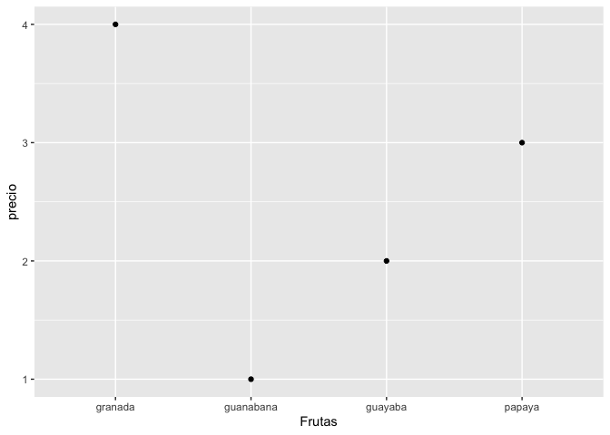

```r
library(ggplot2)
ggplot(precio, aes(x = Frutas, y = precio))+
  geom_point()
```

Como puedes observar, primero se indica el dataset que se usará como primer argumento de la función ggplot, seguido del argumento *aes*, donde entre paréntesis se indica el nombre de las columnas que queremos que vayan en el eje x y en el eje y.

ggplot trabaja en capas, por lo que después de indicarle las variables, le ponemos un signo *+* y añadimos la capa del gráfico que queremos, en este caso el `geom_point()`. Si quieres saber más de cómo funciona ggplot, puedes consultar su [cheat sheet](https://github.com/rstudio/cheatsheets/blob/master/data-visualization-2.1.pdf).

# Exportar los datos

Finalmente, exportaremos los datos obtenidos a un archivo separado por tabs para poder acceder al precio de las frutas y si número siempre que queramos sin tener que hacer todo el proceso de nuevo.

```r
write.table(final, file = "frutas_final.txt", sep = "\t", quote = F, row.names = F )
```